# Pond_sem1_m11

2024-08-09

```
##   cod_transacao     cod_prod cod_vendedor             cod_loja             data
## 1  9.883244e+13  88306780994          416                PR_98 29/06/2019 12:00
## 2  9.883244e+13 571123564033          416                PR_98 29/06/2019 12:00
## 3  2.257775e+13 145338904399          793 SP Capital Centro_85 06/06/2019 20:00
## 4  2.257775e+13 725969988687          793 SP Capital Centro_85 06/06/2019 20:00
## 5  2.257775e+13 509299973007          793 SP Capital Centro_85 06/06/2019 20:00
## 6  2.257775e+13 145338904399          793 SP Capital Centro_85 06/06/2019 20:00
##   quantidade  preco
## 1          4 407,41
## 2          3 216,26
## 3          1  60,79
## 4          4 208,12
## 5          2 140,24
## 6          4  248,4
```

```
## 'data.frame':    305 obs. of  7 variables:
##  $ cod_transacao: num  9.88e+13 9.88e+13 2.26e+13 2.26e+13 2.26e+13 ...
##  $ cod_prod     : num  8.83e+10 5.71e+11 1.45e+11 7.26e+11 5.09e+11 ...
##  $ cod_vendedor : int  416 416 793 793 793 793 793 830 830 830 ...
##  $ cod_loja     : chr  "PR_98" "PR_98" "SP Capital Centro_85" "SP Capital Centro_85" ...
##  $ data         : chr  "29/06/2019 12:00" "29/06/2019 12:00" "06/06/2019 20:00" "06/06/2019 20:00" ...
##  $ quantidade   : int  4 3 1 4 2 4 4 3 4 2 ...
##  $ preco        : chr  "407,41" "216,26" "60,79" "208,12" ...
```

```
##  cod_transacao          cod_prod          cod_vendedor     cod_loja
##  Min.   :6.948e+11   Min.   :2.411e+10   Min.   :  4.0   Length:305
##  1st Qu.:2.136e+13   1st Qu.:1.453e+11   1st Qu.:350.0   Class :character
##  Median :4.650e+13   Median :3.971e+11   Median :514.0   Mode  :character
##  Mean   :4.693e+13   Mean   :4.071e+11   Mean   :515.4
##  3rd Qu.:7.454e+13   3rd Qu.:5.711e+11   3rd Qu.:751.0
##  Max.   :9.940e+13   Max.   :9.650e+11   Max.   :996.0
##      data             quantidade    preco
##  Length:305         Min.   :1    Length:305
##  Class :character   1st Qu.:2    Class :character
##  Mode  :character   Median :3    Mode  :character
##                     Mean   :3
##                     3rd Qu.:4
##                     Max.   :5
```

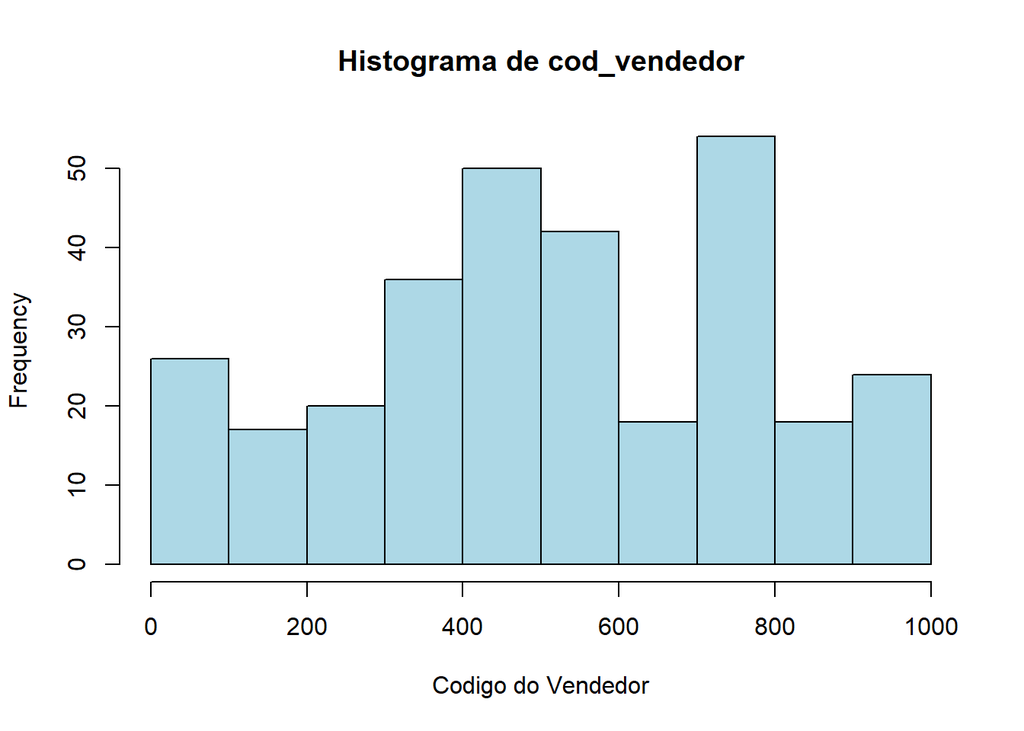

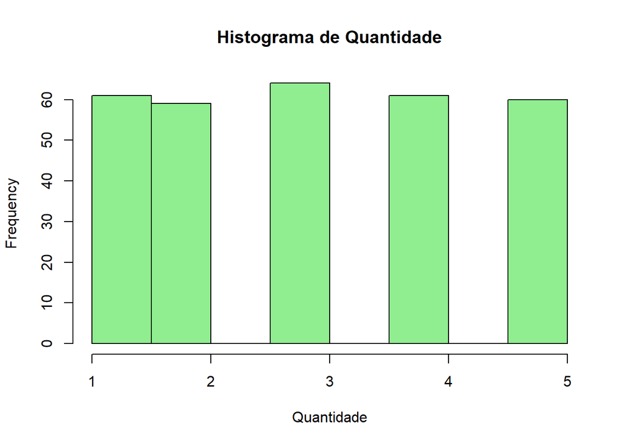

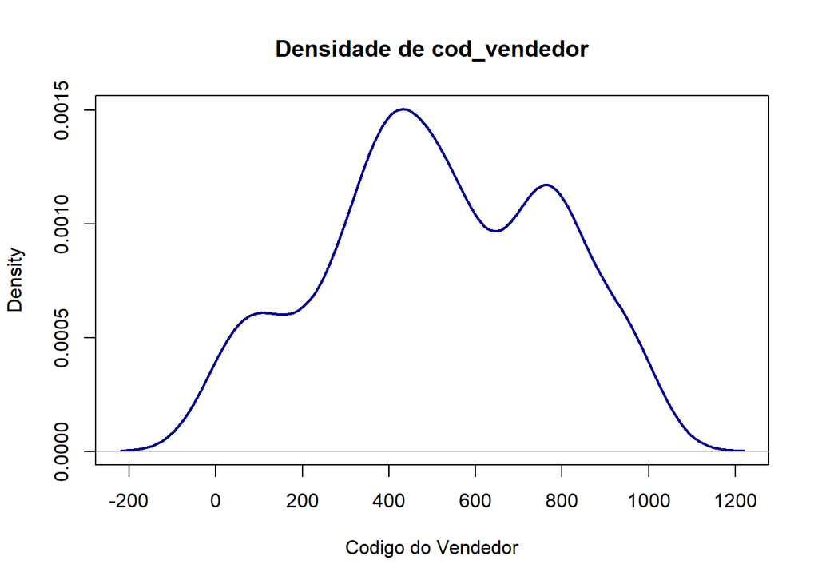

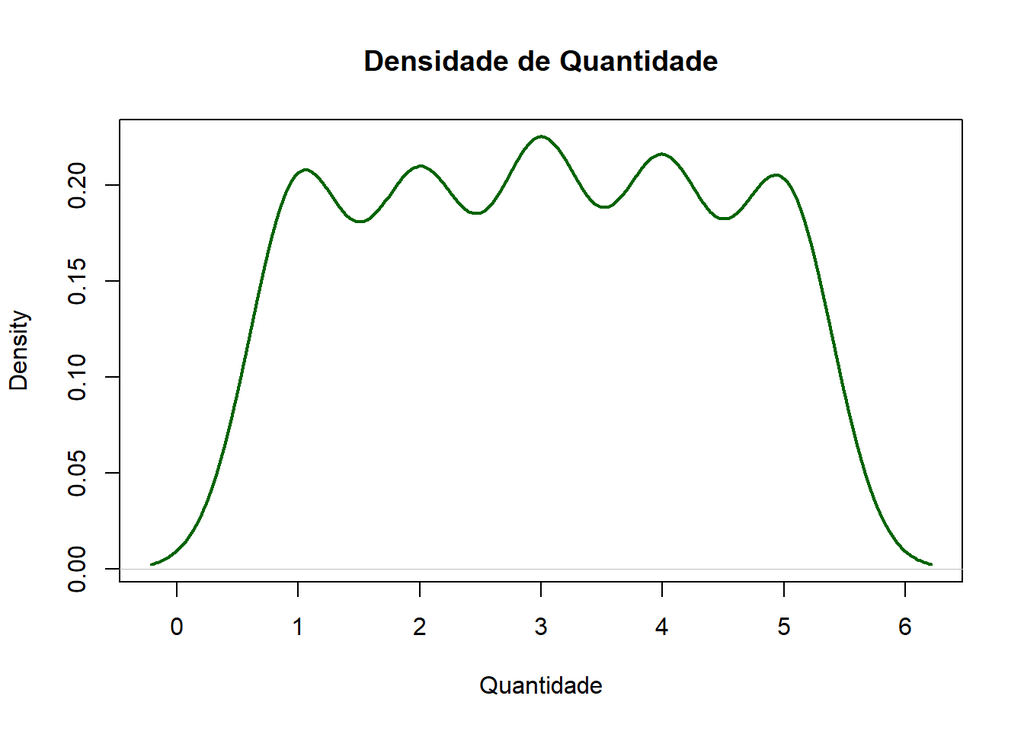

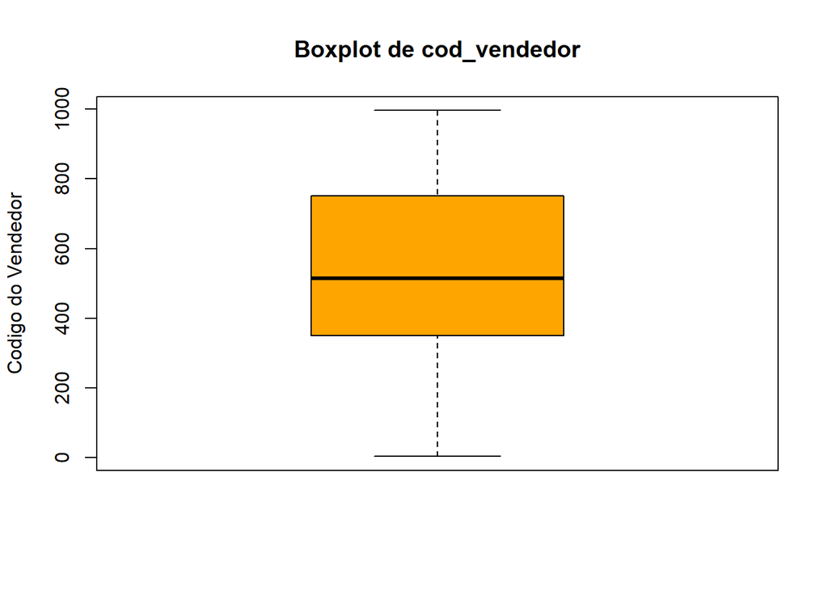

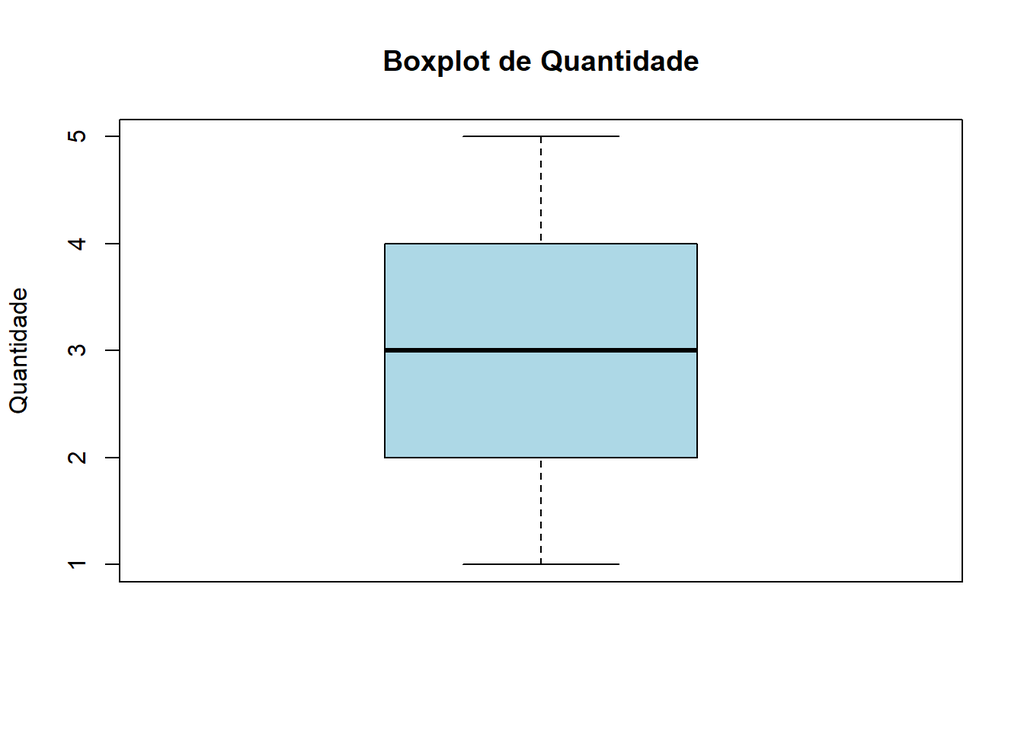

```
## integer(0)
```

```
## integer(0)
```

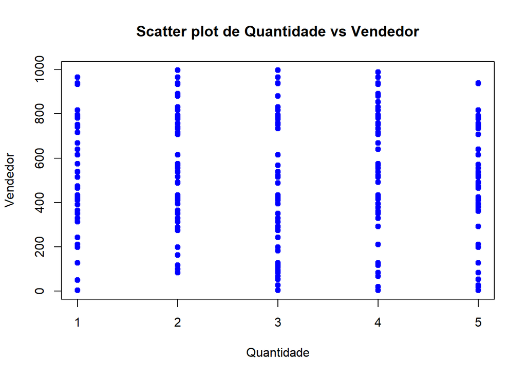

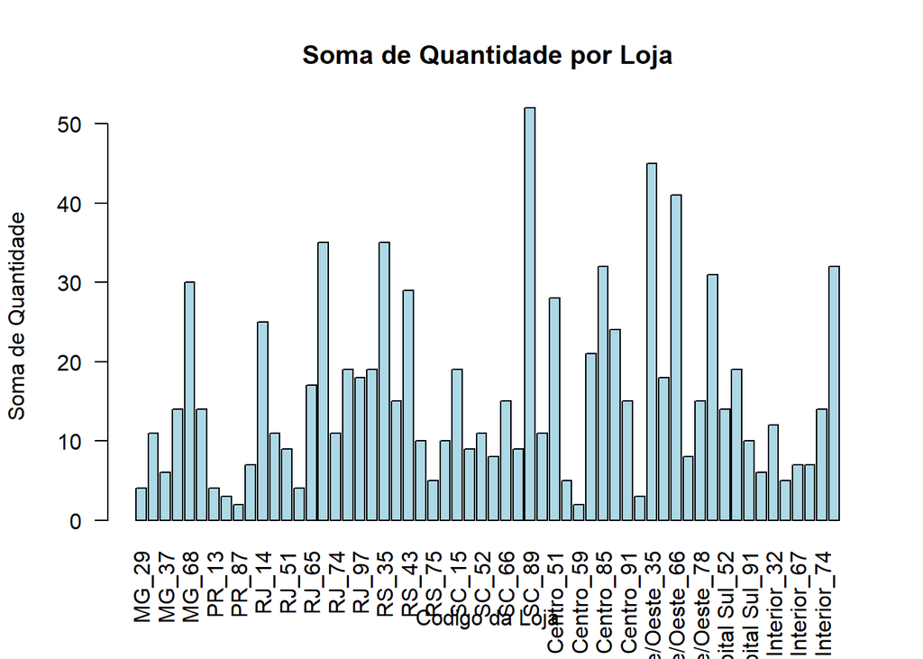

```
##              cod_vendedor  quantidade
## cod_vendedor   1.00000000 -0.08686801
## quantidade    -0.08686801  1.00000000
```

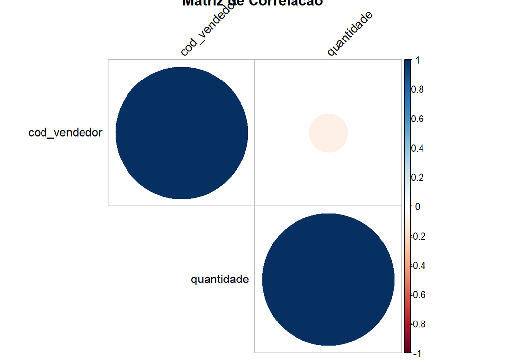

```
## Importance of components:
##                           PC1    PC2
## Standard deviation     1.0425 0.9556
## Proportion of Variance 0.5434 0.4566
## Cumulative Proportion  0.5434 1.0000
```

```
## [1] 0.543434 0.456566
```

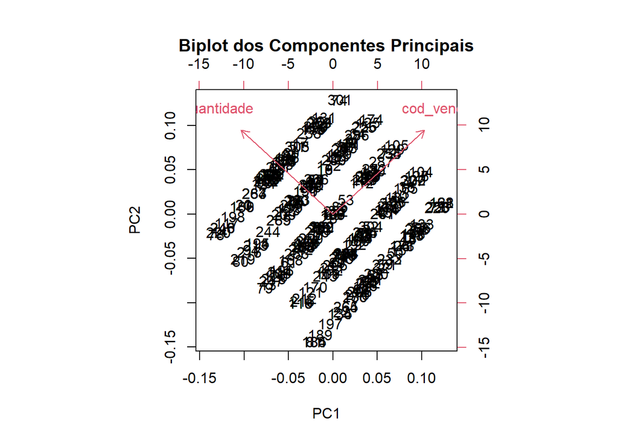

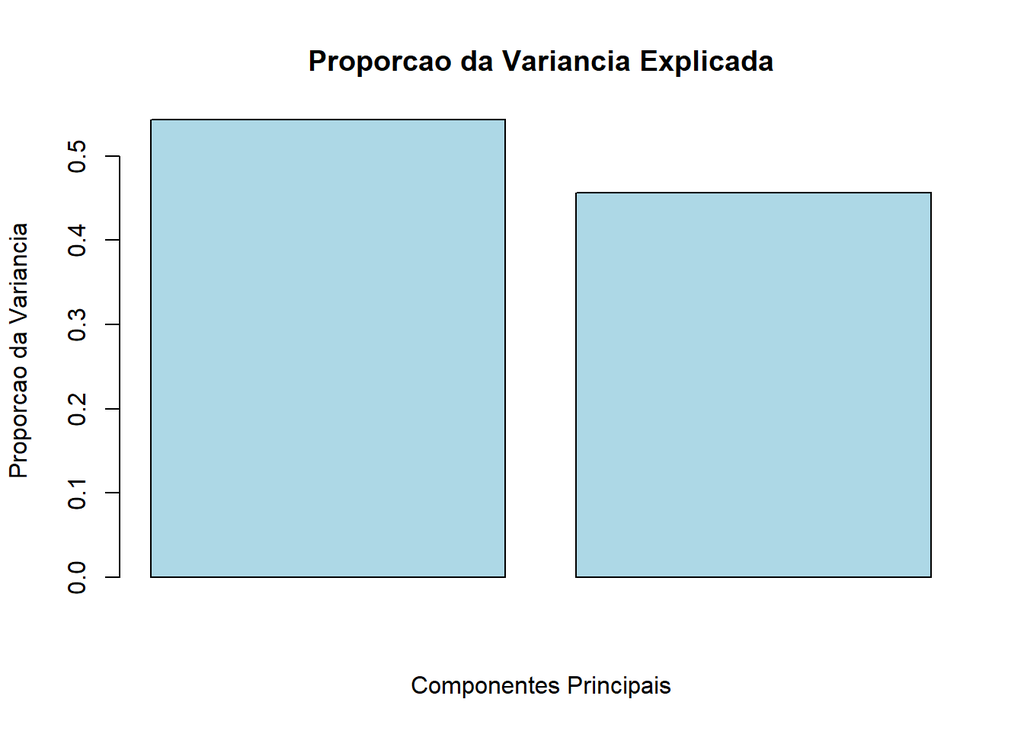

```
## [1] 0.543434 0.456566
```

1. **id_employee**  
   Identificador de cada funcionário.
2. **name**  
   Nome do funcionário.
3. **surname**  
   Sobrenome do funcionário.
4. **cpf**  
   O CPF do funcionário.
5. **status**  
   Status do funcionário, representando se ele ainda está ativo, de saída ou já saiu.
6. **role**  
   A posição do funcionário no organograma da empresa.
7. **initial_date**  
   Data de início do funcionário na empresa ou no cargo atual.
8. **end_date**  
   Data final do funcionário atuando no cargo ou na empresa.
9. **store_id**  
   ID da loja em que o funcionário atua.

PC1: Representa a direção no espaço dos dados que maximiza a variância. No caso de apenas duas variáveis, ele pode refletir uma combinação linear dessas variáveis, maximizando a separação entre os dados.

PC2: O componente é ortogonal ao primeiro e captura a próxima maior quantidade de variância nos dados.

Interpretação: Com duas variáveis numéricas, a utilidade prática do PCA é limitada. Neste caso, os dois componentes principais capturam toda a variância disponível, e a interpretação dos componentes pode não fornecer insights adicionais além do que foi tratado.

- Número Limitado de Variáveis Numéricas:

A análise foi limitada pela disponibilidade de apenas duas variáveis numéricas. Isso restringiu a complexidade da análise multivariada e a profundidade dos insights que podem ser descobertos em um contexto geral.

Possível melhorias:

- Expansão do Conjunto de Dados:

Incluir variáveis vindas de outras tabelas, tanto numéricas quanto categóricas, enriqueceria a análise, utilizando técnicas mais robustas como regressão múltipla, clustering, e PCA multivariado.